# How Economy and Healthcare Impact Child Welfare

```python
from google.colab import files
uploaded = files.upload()
```

Upload widget is only available when the cell has been executed in the current browser session. Please rerun this cell to enable.

```
Saving unicef_metadata.csv to unicef_metadata.csv
```

```python
import pandas as pd
df = pd.read_csv('unicef_metadata.csv')
df.head()
```

|  | country | alpha_2_code | alpha_3_code | numeric_code | year | Population, total | GDP per capita (constant 2015 US$) | GNI (current US$) | Inflation, consumer prices (annual %) | Life expectancy at birth, total (years) | Military expenditure (% of GDP) | Fossil fuel energy consumption (% of total) | GDP growth (annual %) | Birth rate, crude (per 1,000 people) | Hospital beds (per 1,000 people) |
| --- | --- | --- | --- | --- | --- | --- | --- | --- | --- | --- | --- | --- | --- | --- | --- |
| 0 | Afghanistan | AF | AFG | 4 | 1960 | 9035043.0 | NaN | 5.488888e+08 | NaN | 32.535 | NaN | NaN | NaN | 50.340 | 0.170627 |
| 1 | Afghanistan | AF | AFG | 4 | 1961 | 9214083.0 | NaN | 5.600000e+08 | NaN | 33.068 | NaN | NaN | NaN | 50.443 | NaN |
| 2 | Afghanistan | AF | AFG | 4 | 1962 | 9404406.0 | NaN | 5.577778e+08 | NaN | 33.547 | NaN | NaN | NaN | 50.570 | NaN |
| 3 | Afghanistan | AF | AFG | 4 | 1963 | 9604487.0 | NaN | 7.666667e+08 | NaN | 34.016 | NaN | NaN | NaN | 50.703 | NaN |
| 4 | Afghanistan | AF | AFG | 4 | 1964 | 9814318.0 | NaN | 8.155556e+08 | NaN | 34.494 | NaN | NaN | NaN | 50.831 | NaN |

```python
!pip install plotnine
!pip install geopandas
```

```python
relevant_columns = [
    'country', 'year',
    'GDP per capita (constant 2015 US$)',
    'Life expectancy at birth, total (years)',
    'Military expenditure (% of GDP)',
    'Hospital beds (per 1,000 people)'
]

clean_df = df[relevant_columns]

clean_df = clean_df.dropna(subset=[
    'Life expectancy at birth, total (years)',
    'Military expenditure (% of GDP)'
])


clean_df.head()
```

|  | country | year | GDP per capita (constant 2015 US$) | Life expectancy at birth, total (years) | Military expenditure (% of GDP) | Hospital beds (per 1,000 people) |
| --- | --- | --- | --- | --- | --- | --- |
| 10 | Afghanistan | 1970 | NaN | 37.418 | 1.629606 | 0.199 |
| 13 | Afghanistan | 1973 | NaN | 39.003 | 1.868910 | NaN |
| 14 | Afghanistan | 1974 | NaN | 39.550 | 1.610825 | NaN |
| 15 | Afghanistan | 1975 | NaN | 40.100 | 1.722066 | NaN |
| 16 | Afghanistan | 1976 | NaN | 40.645 | 2.046087 | NaN |

```python
from google.colab import files
uploaded = files.upload()

import pandas as pd
df = pd.read_csv('unicef_metadata.csv')
```

Upload widget is only available when the cell has been executed in the current browser session. Please rerun this cell to enable.

```
Saving unicef_metadata.csv to unicef_metadata.csv
```

```python
relevant_columns = [
    'country', 'year',
    'Military expenditure (% of GDP)'
]

clean_df = df[relevant_columns]


clean_df = clean_df.dropna(subset=['Military expenditure (% of GDP)'])
```

```python
latest_year = clean_df['year'].max()

bar_data = clean_df[clean_df['year'] == latest_year]

top10_military = bar_data.sort_values(by='Military expenditure (% of GDP)', ascending=False).head(10)
```

[figure not shown]

```python
from plotnine import *

(
    ggplot(top10_military, aes(x='country', y='Military expenditure (% of GDP)', order=top10_military['Military expenditure (% of GDP)'].tolist()[::-1])) +
    coord_flip() +
    labs(title='Top 10 Countries by Military Expenditure (% of GDP)',
         x='Country', y='Military Expenditure (% of GDP)') +
    scale_x_discrete(limits=top10_military['country'].tolist()[::-1])
)
```

## Military Spending vs Social Development

Military expenditure often reflects a nation’s strategic priorities. While defense is essential, excessive spending on the military can sometimes divert resources away from critical sectors like education, health, and child welfare. In many of the countries highlighted here, this heavy investment in defense is accompanied by low investments in social infrastructure.

```python
!pip install geopandas
```

```python
!wget https://www.naturalearthdata.com/http//www.naturalearthdata.com/download/110m/cultural/ne_110m_admin_0_countries.zip
!unzip ne_110m_admin_0_countries.zip -d ne_countries
```

[output not shown]

```python
import geopandas as gpd


world = gpd.read_file("ne_countries/ne_110m_admin_0_countries.shp")


world.head()
```

|  | featurecla | scalerank | LABELRANK | SOVEREIGNT | SOV_A3 | ADM0_DIF | LEVEL | TYPE | TLC | ADMIN | ... | FCLASS_TR | FCLASS_ID | FCLASS_PL | FCLASS_GR | FCLASS_IT | FCLASS_NL | FCLASS_SE | FCLASS_BD | FCLASS_UA | geometry |
| --- | --- | --- | --- | --- | --- | --- | --- | --- | --- | --- | --- | --- | --- | --- | --- | --- | --- | --- | --- | --- | --- |
| 0 | Admin-0 country | 1 | 6 | Fiji | FJI | 0 | 2 | Sovereign country | 1 | Fiji | ... | None | None | None | None | None | None | None | None | None | MULTIPOLYGON (((180 -16.06713, 180 -16.55522, ... |
| 1 | Admin-0 country | 1 | 3 | United Republic of Tanzania | TZA | 0 | 2 | Sovereign country | 1 | United Republic of Tanzania | ... | None | None | None | None | None | None | None | None | None | POLYGON ((33.90371 -0.95, 34.07262 -1.05982, 3... |
| 2 | Admin-0 country | 1 | 7 | Western Sahara | SAH | 0 | 2 | Indeterminate | 1 | Western Sahara | ... | Unrecognized | Unrecognized | Unrecognized | None | None | Unrecognized | None | None | None | POLYGON ((-8.66559 27.65643, -8.66512 27.58948... |
| 3 | Admin-0 country | 1 | 2 | Canada | CAN | 0 | 2 | Sovereign country | 1 | Canada | ... | None | None | None | None | None | None | None | None | None | MULTIPOLYGON (((-122.84 49, -122.97421 49.0025... |
| 4 | Admin-0 country | 1 | 2 | United States of America | US1 | 1 | 2 | Country | 1 | United States of America | ... | None | None | None | None | None | None | None | None | None | MULTIPOLYGON (((-122.84 49, -120 49, -117.0312... |

5 rows × 169 columns

```python
latest_year = clean_df['year'].max()
map_data = clean_df[clean_df['year'] == latest_year]

world_map = world.merge(map_data, how='left', left_on='NAME', right_on='country')
```

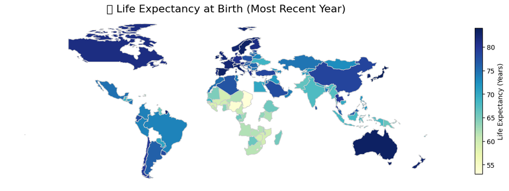

```python
import matplotlib.pyplot as plt

fig, ax = plt.subplots(figsize=(15, 8))
world_map.plot(
    column='Life expectancy at birth, total (years)',
    cmap='YlGnBu',
    linewidth=0.8,
    ax=ax,
    edgecolor='0.8',
    legend=True,
    legend_kwds={'label': "Life Expectancy (Years)", 'shrink': 0.5}
)

ax.set_title('🌍 Life Expectancy at Birth (Most Recent Year)', fontdict={'fontsize': 16})
ax.axis('off')
plt.show()
```

Life Expectancy Around the World

The map above shows the most recent estimates of **life expectancy at birth** across countries. Life expectancy is a strong indicator of a nation’s healthcare quality, economic stability, and public health investment.

The **color gradient** ranges from: - **Dark blue**: Countries with **high life expectancy** (e.g., Australia, Switzerland). - **Lighter greenish shades**: Countries with **moderate life expectancy**. - **White regions**: Countries where **life expectancy data is unavailable** or could not be matched.

This visualization clearly highlights the disparities between developed and developing regions. Sub-Saharan Africa, for example, shows noticeably lower life expectancy, which is often linked to limited healthcare access, undernutrition, and conflict.

> **Insight:** Countries with darker shades (higher life expectancy) tend to invest more in public health and social support. The white gaps remind us of data inequality; some regions lack reliable health tracking, which hinders informed policy making.

```python
from google.colab import files
uploaded = files.upload()
```

Upload widget is only available when the cell has been executed in the current browser session. Please rerun this cell to enable.

```
Saving unicef_indicator_1.csv to unicef_indicator_1.csv
```

```python
import pandas as pd

indicator_1 = pd.read_csv('unicef_indicator_1.csv')
indicator_1.head()
```

|  | country | alpha_2_code | alpha_3_code | numeric_code | indicator | time_period | obs_value | sex | unit_multiplier | unit_of_measure | observation_status | observation_confidentaility | time_period_activity_related_to_when_the_data_are_collected | current_age |
| --- | --- | --- | --- | --- | --- | --- | --- | --- | --- | --- | --- | --- | --- | --- |
| 0 | Afghanistan | AF | AFG | 4 | Out-of-school rate for youth of upper secondar... | 2018 | 68.68825 | Female | NaN | % | NaN | NaN | NaN | Total |
| 1 | Afghanistan | AF | AFG | 4 | Out-of-school rate for youth of upper secondar... | 2018 | 43.78052 | Male | NaN | % | NaN | NaN | NaN | Total |
| 2 | Afghanistan | AF | AFG | 4 | Out-of-school rate for youth of upper secondar... | 2018 | 55.89854 | Total | NaN | % | NaN | NaN | NaN | Total |
| 3 | Albania | AL | ALB | 8 | Out-of-school rate for youth of upper secondar... | 2020 | 15.10066 | Female | NaN | % | NaN | NaN | NaN | Total |
| 4 | Albania | AL | ALB | 8 | Out-of-school rate for youth of upper secondar... | 2020 | 21.92466 | Male | NaN | % | NaN | NaN | NaN | Total |

```python
edu_latest = indicator_1[indicator_1['sex'] == 'Total']
edu_latest = edu_latest.groupby('country')[['time_period', 'obs_value']].max().reset_index()
edu_latest.rename(columns={'obs_value': 'Out_of_School_Rate'}, inplace=True)


scatter_merged = pd.merge(
    clean_df,
    edu_latest,
    left_on=['country', 'year'],
    right_on=['country', 'time_period'],
    how='inner'
)

scatter_merged = scatter_merged.dropna(subset=['Hospital beds (per 1,000 people)', 'Out_of_School_Rate'])
```

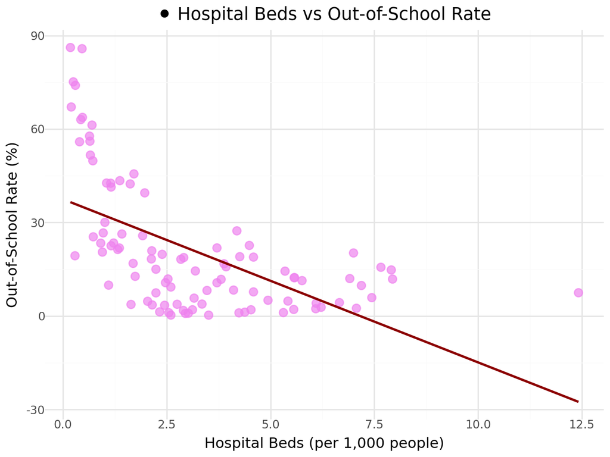

```python
from plotnine import *

(
    ggplot(scatter_merged, aes(x='Hospital beds (per 1,000 people)', y='Out_of_School_Rate')) +
    geom_point(color='violet', size=3, alpha=0.7) +
    geom_smooth(method='lm', color='darkred', se=False) +
    labs(
        title='⚫ Hospital Beds vs Out-of-School Rate',
        x='Hospital Beds (per 1,000 people)',
        y='Out-of-School Rate (%)'
    ) +
    theme_minimal()
)
```

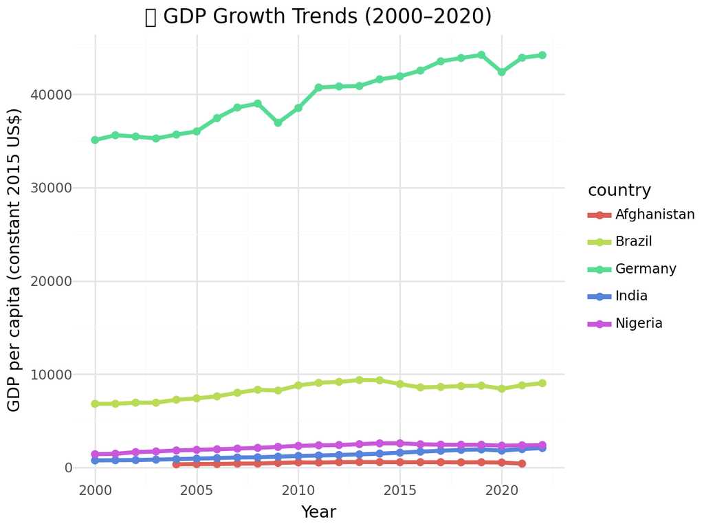

```python
from plotnine import *


countries = ['India', 'Nigeria', 'Brazil', 'Germany', 'Afghanistan']


gdp_data = clean_df[
    (clean_df['country'].isin(countries)) &
    (clean_df['year'] >= 2000) &
    (~clean_df['GDP per capita (constant 2015 US$)'].isnull())
]


(
    ggplot(gdp_data, aes(x='year', y='GDP per capita (constant 2015 US$)', color='country')) +
    geom_line(size=1.5) +
    geom_point(size=2) +
    labs(title='📈 GDP Growth Trends (2000–2020)',
         x='Year',
         y='GDP per capita (constant 2015 US$)') +
    theme_minimal()
)
```

## GDP Growth Trends Over Time

**Insight:** Countries with stable GDP growth are better positioned to invest in child welfare, while those with volatile economies may struggle with consistent public spending — impacting both healthcare and education outcomes.

# Conclusion

This report has highlighted the deep connections between a country’s **economic strength**, **healthcare infrastructure**, and overall **child welfare outcomes**.

Through visualising key indicators such as **life expectancy**, **military expenditure**, **healthcare capacity**, and **GDP growth trends**, clear patterns emerged:

- Countries with **robust healthcare systems** and stable economies tend to offer better conditions for their populations, reflected in higher life expectancy and improved social outcomes.
- Excessive focus on areas like **military spending** often correlates with underinvestment in critical sectors such as health and education.
- Nations facing economic volatility or lacking healthcare infrastructure frequently struggle with lower human development indicators, directly impacting children’s survival, education, and future opportunities.

These insights emphasize that sustainable development requires balanced investment in both economic growth and social infrastructure. For global organizations like UNICEF, such data-driven analyses are vital to advocate for smarter policy decisions that prioritize child welfare.

> Ensuring every child has access to healthcare, education, and a safe environment is not just a social responsibility , it’s a foundation for long-term national prosperity.